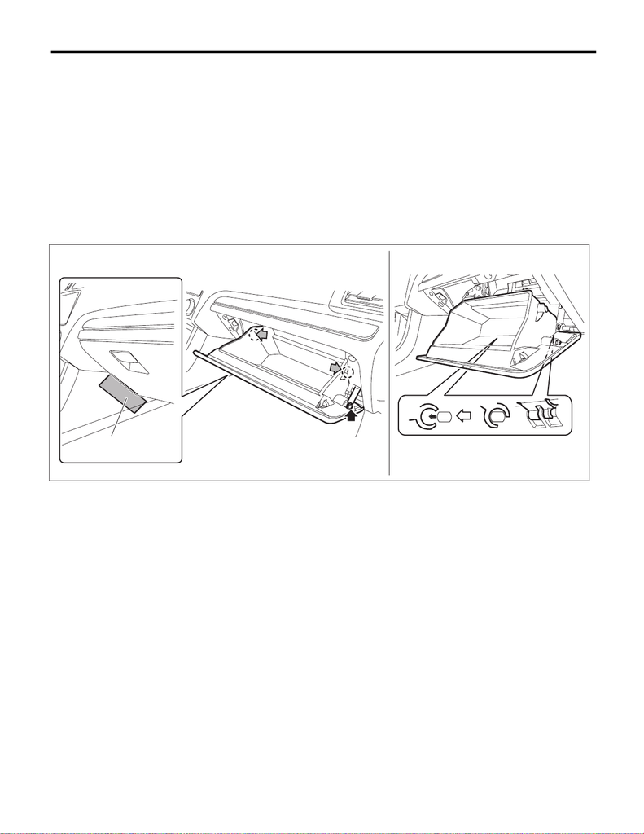

EI-63

Glove Box

EXTERIOR/INTERIOR TRIM

19.Glove Box

A: REMOVAL

NOTE:

1) Disconnect the ground cable from battery. <Ref. to NT-5, BATTERY, NOTE, Note.>

NOTE:

For models other than STI model, disconnect the ground terminal from battery sensor.

2) Remove the pocket assembly.

(1) Attach the protective tape (a) to the panel center LWR.

(2) Remove the damper COMPL - pocket.

(3) Release the stoppers and remove the pocket assembly by pulling it toward you.

EI-03419

(a)

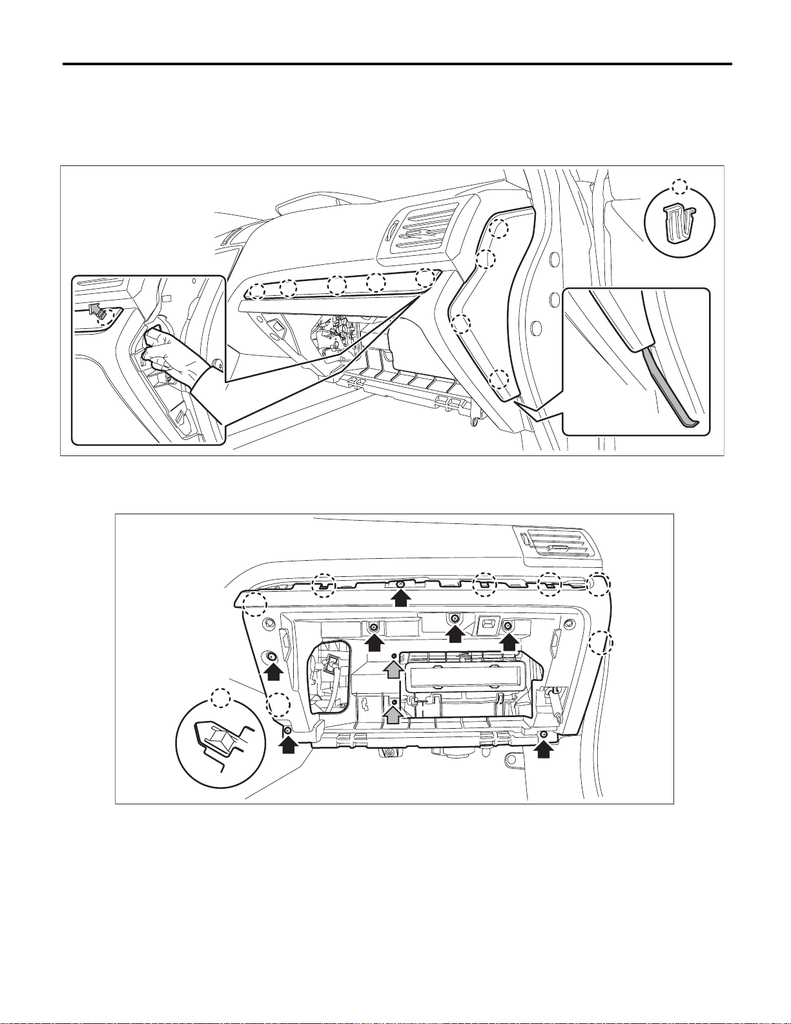

EI-64

Glove Box

EXTERIOR/INTERIOR TRIM

3) Remove the back panel - pocket.

(1) Remove the clips, and remove the cover - instrument panel side RH.

NOTE:

Remove the cover - instrument panel side RH by using a plastic remover.

(2) Release the clips, and remove the ornament - panel assembly passenger.

NOTE:

To facilitate the removal, push the clip of the ornament - panel assembly passenger from the backside.

(3) Remove the screws, claws and harness clamp, then remove the back panel - pocket.

(4) Disconnect the glove box light LED connector.

EI-04376

EI-03691

[figure not shown]

EI-65

Glove Box

EXTERIOR/INTERIOR TRIM

B: INSTALLATION

1) Connect the glove box light LED connector.

2) Install the back panel - pocket.

3) Install the ornament - panel assembly passenger.

6) Install the cover - instrument panel side RH.

7) Connect the battery ground terminal. <Ref. to NT-5, BATTERY, NOTE, Note.>

NOTE:

For models other than STI model, connect the ground terminal to battery sensor.